# B2-Spirit — Rapport final

# 3 L’application Shiny — exploration interactive

Au-delà des graphiques statiques de ce rapport, nous avons développé une **application Shiny** (dossier `shiny/`) centrée sur un **globe terrestre 3D interactif**. Les deux figures ci-dessous en sont des captures d’écran : **elles ne sont pas générées dans ce rapport mais dans l’application**, que le lecteur est invité à lancer pour interagir avec ces visualisations.

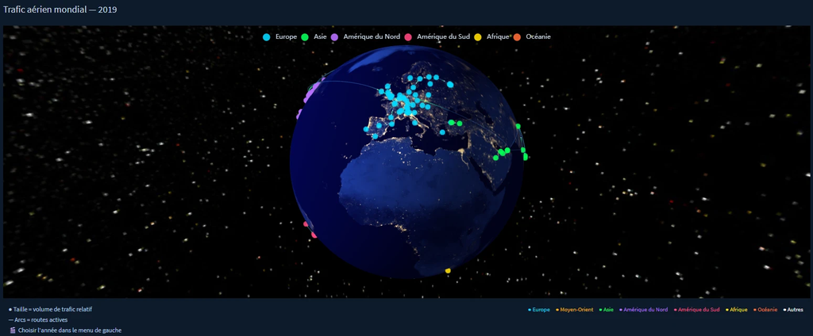

Application Shiny — globe 3D du trafic aérien mondial (2019). Capture d’écran (figure non générée dans le rapport).

Le globe affiche les principaux aéroports — **taille proportionnelle au volume de trafic, couleur par région** — et les routes actives sous forme d’arcs. Un menu permet de **choisir l’année (2019-2022)** et de **filtrer par région** : on visualise immédiatement la forte densité européenne et nord-américaine, ainsi que l’effondrement du trafic pendant le COVID en changeant d’année. Cette vue interactive complète la carte statique des corridors (Q3).

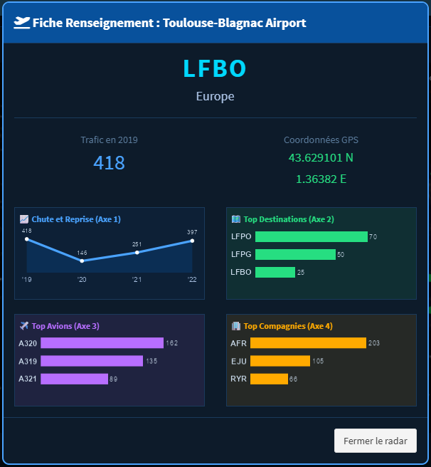

Application Shiny — fiche interactive d’un aéroport (clic sur Toulouse-Blagnac). Capture d’écran (figure non générée dans le rapport).

En **cliquant sur un aéroport**, l’utilisateur ouvre une fiche détaillée qui croise les quatre axes du projet : évolution 2019-2022 du trafic (Axe 1), top destinations (Axe 2), avions les plus fréquents (Axe 3) et compagnies dominantes (Axe 4). Pour **Toulouse-Blagnac (LFBO)**, on retrouve par exemple la signature COVID (418 vols en 2019, creux à 146 en 2020, reprise à 397 en 2022), une desserte dominée par Paris (LFPO, LFPG) et la forte présence d’Air France et d’easyJet. Cette interactivité — impossible à rendre dans un document statique — illustre l’intérêt de l’application Shiny.